# MA615_GroupAssignment

Becky Yu , Mira Tang , Kecheng Liang , Chaoqun Yin

September 30, 2018

We got the dataset from the [Suspicious Activities Report statistics](https://www.fincen.gov/reports/sar-stats) tool. After filtering specific industries (Insurance Company, Loan or Finance Company, Money Services BUsiness and Securities/Futures) and suspicious activities(Fraud), we got a dataset with 43454 observations of 8 variables. Looking into the data, we found that observations with “[Total]” entries were summarized data that should be seprated from raw data, so we removed those entires and ended with 23890 observations.

## Data Cleaning

```r
#Import data
Finance <- read.csv("SARStats.csv")
#View(Finance)
summary(Finance)
```

```
##    Year.Month             State
##  2017   :9310   California   : 3425
##  2016   :8994   New York     : 3214
##  2018   :7729   Texas        : 2713
##  2015   :7273   Florida      : 1755
##  2014   :5609   Massachusetts: 1684
##  2013   :3665   Illinois     : 1499
##  (Other): 874   (Other)      :29164
##                           Industry             Suspicious.Activity
##  [Total]                      :  384   Other Fraud (Type):9137
##  Insurance Company            : 3138   Wire              :9130
##  Loan or Finance Company      : 1129   Check             :6905
##  Money Services Business (MSB):17832   Credit/Debit Card :6046
##  Securities/Futures           :20971   ACH               :5875
##                                        Mail              :2035
##                                        (Other)           :4326
##           Regulator               Product
##  IRS           :17538   [Total]       :9296
##  SEC           :12240   Debit Card    :8270
##  [Total]       : 4789   Other         :7041
##  OCC           : 4537   Credit Card   :4352
##  FRB           : 2655   Prepaid Access:3511
##  Not Applicable:  707   Mutual Fund   :2585
##  (Other)       :  988   (Other)       :8399
##                    Instrument        Count
##  [Total]                :19564   1      :16698
##  Funds Transfer         : 7924   2      : 5974
##  U.S. Currency          : 4262   3      : 3208
##  Personal/Business Check: 4186   4      : 2073
##  Foreign Currency       : 1994   5      : 1241
##  Other                  : 1914   6      : 1140
##  (Other)                : 3610   (Other):13120
```

```r
#Eliminate meaningless data
Finance <- filter(Finance, !(str_detect(string = Finance$State,pattern = "\\[Total\\]")))
Finance <- filter(Finance, !(str_detect(string = Finance$Industry,pattern = "\\[Total\\]")))
Finance <- filter(Finance, !(str_detect(string = Finance$Product,pattern = "\\[Total\\]")))
Finance <- filter(Finance, !(str_detect(string = Finance$Instrument,pattern = "\\[Total\\]")))
Finance <- filter(Finance, !(str_detect(string = Finance$Suspicious.Activity,pattern = "\\[Total\\]")))
Finance <- filter(Finance, !(str_detect(string = Finance$Regulator,pattern = "\\[Total\\]")))
Finance <- filter(Finance, !(str_detect(string = Finance$Year.Month,pattern = "\\[Total\\]")))

#rename the inappropriate column name
colnames(Finance)[1]<-"Year"

#Transform the type of data
Finance$Count <- as.numeric(Finance$Count)
```

## EDA

### State

Firstly, let us take a quick look at the total count of frauds reported in 2017 for each state:

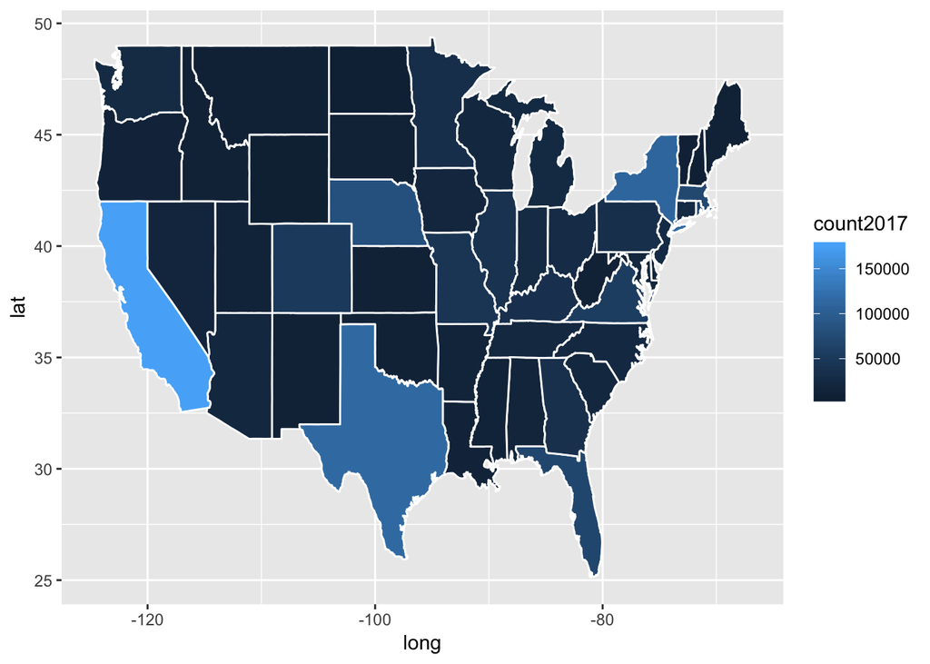

```r
Finance %>%
  group_by(Year,State) %>%
  summarise(State_Total_Count = sum(as.numeric(Count)))-> State1

library(ggplot2)
library(maps)
#load us map data
all_states <- map_data("state")

#mutate the count data into map data
State2017<-State1[which(as.character(State1$Year)=='2017 '),]
State2017$State<-tolower(State2017$State)
s<-State2017$State
for (i in 1:length(s)){
  if (s[i] %in% unique(all_states$region)){
    all_states[which(all_states$region==s[i]),"count2017"]<-State2017$State_Total_Count[i]
  }
}

#plot all states with ggplot
ggplot(all_states)+
  geom_polygon(aes(x=long, y=lat, group = group,fill=count2017),colour="white" )
```

From the American map based the number of fraud cases, we can see that Texas state, California state and New York have more fraud cases in 2017 than any other states. It is an intuitionistic and vivid visualization but lacks details of exact states.

Next, here are the boxplots of total counts of all states per year:

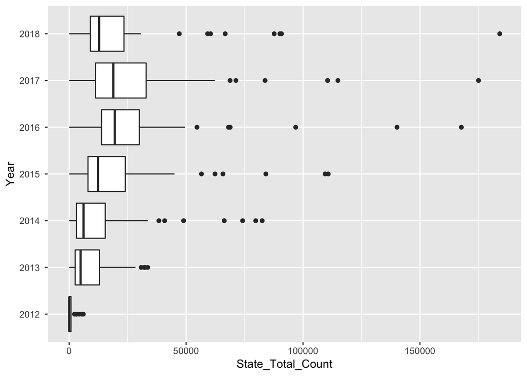

```r
ggplot(State1, aes(x=Year, y=State_Total_Count))+
  geom_boxplot()+
  coord_flip()
```

From the boxplot, we can compare the numbers of fraud cases from 2012 to 2018 easily. From 2012 to 2017, the total number of fraud cases has a obvious trend of increasing.

#### Make a table

```r
#get a summarized dataframe with top five states for each year
Finance %>%
  group_by(Year , State) %>%
  summarise(Total_Count = sum(as.numeric(Count))) %>%
  arrange(Year,desc(Total_Count)) %>%
  slice(1:5) -> State2

#tidy the long table using string concating skills
table1<-aggregate(State~Year,data =State2,paste,collapse=",")
table2<-aggregate(Total_Count~Year,data =State2,paste,collapse=",")

#join the sub tables
table<-left_join(table1,table2,by="Year")
kable(table,caption = "Top five States each year", "html" ) %>%
  kable_styling(bootstrap_options = c("striped", "hover", "condensed"))
```

Top five States each year

| Year | State | Total_Count |
| --- | --- | --- |
| 2012 | California,Indiana,North Carolina,Florida,New York | 6045,5727,5316,4272,3146 |
| 2013 | Massachusetts,California,New York,Kentucky,Rhode Island | 33583,32431,32125,30782,28373 |
| 2014 | Massachusetts,New York,Rhode Island,California,Nebraska | 82535,79759,74172,66306,48920 |
| 2015 | New York,California,Texas,Nebraska,Massachusetts | 110787,109461,84118,65739,62372 |
| 2016 | California,New York,Texas,Nebraska,Massachusetts | 167700,140177,96872,68830,68116 |
| 2017 | California,Texas,New York,Nebraska,Massachusetts | 175031,114916,110504,83762,71301 |
| 2018 | California,Texas,Nebraska,New York,Florida | 184114,90797,90119,87658,66714 |

#### Make a plot

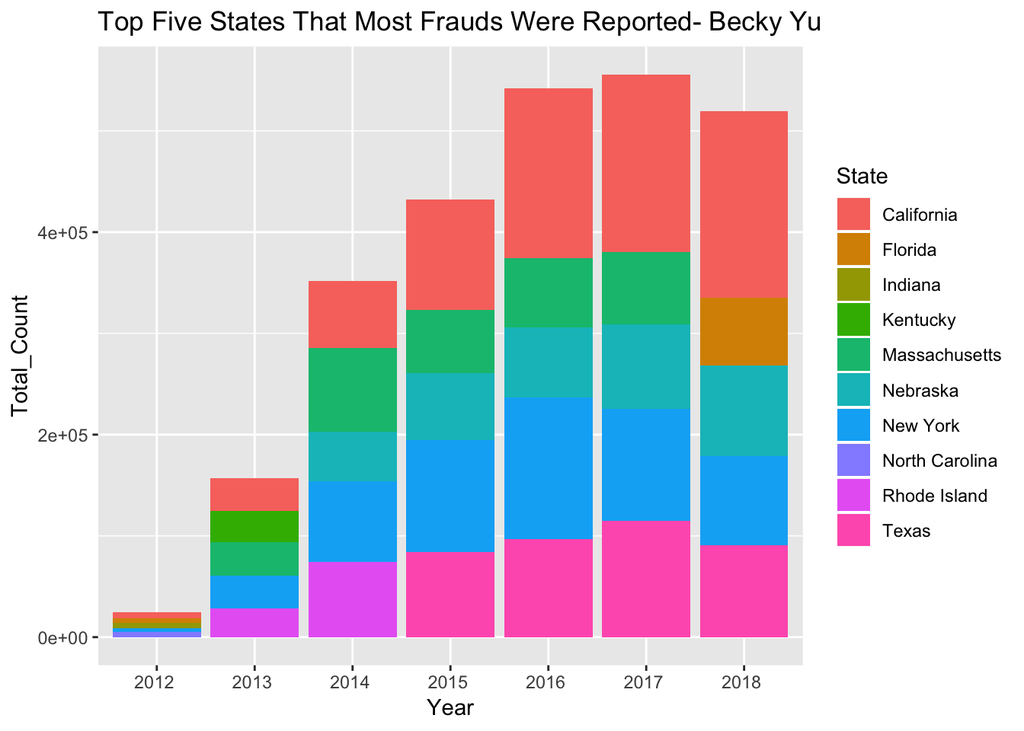

```r
ggplot(State2,aes(x = Year,y = Total_Count,fill = State))+
  geom_bar(stat = 'identity',position = 'stack') +
  labs(title = "Top Five States That Most Frauds Were Reported- Becky Yu")
```

The count of frauds reported increased largely through the last few years. Since the data of 2018 has not been complete yet, we may still predict a trend of growth. California and New York were typically among the top five States that most frauds were reported. Massachusetts ranked first in 2013 and 2014, but ended with fifth in 2015, 2016 and 2017.

### Industry

```r
Finance %>% group_by(Year,Industry)  %>%
  summarize(Count = sum(Count)) %>%
  arrange(Year,desc(Count)) -> Finance.ind
```

#### Make a table

```r
kable(Finance.ind[,c(2,3)], caption = "Securities/Futures Suspicious Activity Reports by Industry" , "html" ) %>%
  kable_styling(bootstrap_options = c("striped", "hover", "condensed")) %>%
  group_rows("2012", 1, 3) %>%
  group_rows("2013", 4, 6) %>%
  group_rows("2014", 7, 10) %>%
  group_rows("2015", 11, 14) %>%
  group_rows("2016", 15, 18) %>%
  group_rows("2017", 19, 22) %>%
  group_rows("2018", 23, 26)
```

Securities/Futures Suspicious Activity Reports by Industry

| Industry | Count |
| --- | --- |
| **2012** |  |
| Money Services Business (MSB) | 27182 |
| Insurance Company | 9797 |
| Securities/Futures | 2579 |
| **2013** |  |
| Money Services Business (MSB) | 247631 |
| Securities/Futures | 198989 |
| Insurance Company | 29279 |
| **2014** |  |
| Securities/Futures | 432317 |
| Money Services Business (MSB) | 364868 |
| Insurance Company | 22727 |
| Loan or Finance Company | 3 |
| **2015** |  |
| Money Services Business (MSB) | 685468 |
| Securities/Futures | 486001 |
| Insurance Company | 23120 |
| Loan or Finance Company | 11969 |
| **2016** |  |
| Money Services Business (MSB) | 1066324 |
| Securities/Futures | 536431 |
| Insurance Company | 27123 |
| Loan or Finance Company | 14131 |
| **2017** |  |
| Money Services Business (MSB) | 969278 |
| Securities/Futures | 580305 |
| Insurance Company | 47178 |
| Loan or Finance Company | 24568 |
| **2018** |  |
| Money Services Business (MSB) | 775374 |
| Securities/Futures | 539040 |
| Insurance Company | 30987 |
| Loan or Finance Company | 5732 |

#### Make a plot

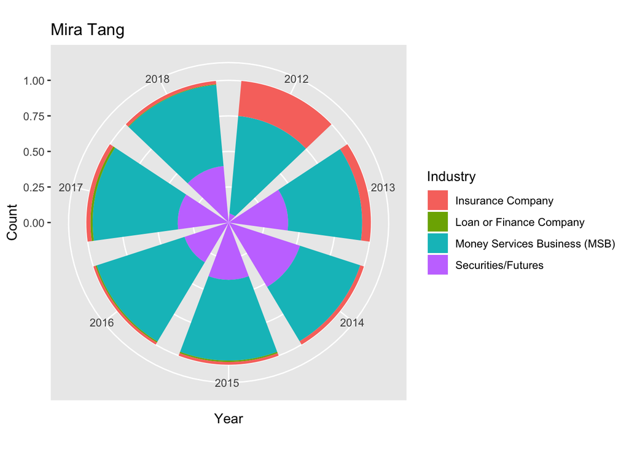

```r
ggplot(Finance.ind,aes(x = Year , Count ,fill = Industry)) +
  geom_bar(stat = "identity",position = "fill",width = 0.8) +
  coord_polar(theta = "x") +
  labs(title = "Mira Tang")
```

### Suspicious Activities

```r
#Select some useful columns from the database
suspicion <- select(Finance, Year, Suspicious.Activity, Count)

# Change the column's name
colnames(suspicion)[1] <- "Year"
suspicion %>%
  group_by(Year, Suspicious.Activity) %>%
  summarize(Count = sum(Count)) %>%
  arrange(Year, desc(Count)) %>%
  slice(1:5) -> sus.table
```

#### Make a table

```r
kable(sus.table, caption = "Top 5 Reported Susicious Activities by Years") %>%
  kable_styling(bootstrap_options = c("striped") )
```

Top 5 Reported Susicious Activities by Years

| Year | Suspicious.Activity | Count |
| --- | --- | --- |
| 2012 | Other Fraud (Type) | 13938 |
| 2012 | ACH | 9900 |
| 2012 | Wire | 6859 |
| 2012 | Check | 3767 |
| 2012 | Credit/Debit Card | 2245 |
| 2013 | Wire | 187095 |
| 2013 | Other Fraud (Type) | 72266 |
| 2013 | Check | 66244 |
| 2013 | ACH | 63171 |
| 2013 | Credit/Debit Card | 58805 |
| 2014 | Wire | 275259 |
| 2014 | Other Fraud (Type) | 140279 |
| 2014 | ACH | 127467 |
| 2014 | Credit/Debit Card | 126664 |
| 2014 | Check | 98299 |
| 2015 | Wire | 312110 |
| 2015 | Other Fraud (Type) | 278494 |
| 2015 | Credit/Debit Card | 192922 |
| 2015 | ACH | 181390 |
| 2015 | Check | 157384 |
| 2016 | Other Fraud (Type) | 519922 |
| 2016 | Wire | 513993 |
| 2016 | Check | 195172 |
| 2016 | ACH | 183941 |
| 2016 | Credit/Debit Card | 170285 |
| 2017 | Other Fraud (Type) | 486738 |
| 2017 | Wire | 412141 |
| 2017 | Credit/Debit Card | 239798 |
| 2017 | ACH | 217305 |
| 2017 | Check | 200797 |
| 2018 | Other Fraud (Type) | 485287 |
| 2018 | Wire | 313448 |
| 2018 | ACH | 188977 |
| 2018 | Credit/Debit Card | 159663 |
| 2018 | Check | 153828 |

#### Make a plot

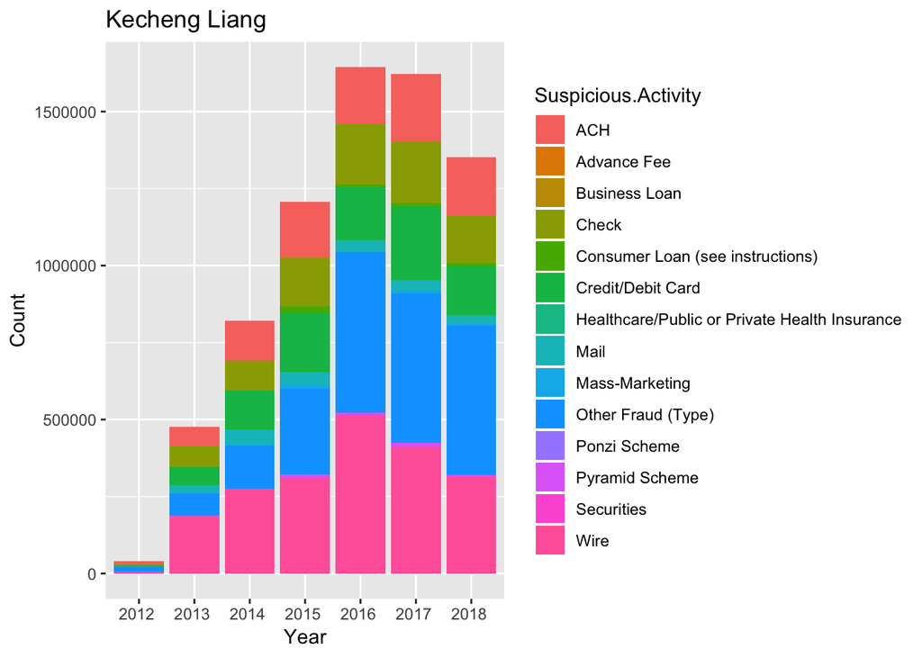

```r
ggplot(suspicion, aes(x = Year, y = Count, fill = Suspicious.Activity)) +
  geom_col(position = "stack") +
  labs(title = "Kecheng Liang")
```

The graph shows that we should pay more attetion on wire, credit/debit card, and check.

### Regulator

[output not shown]

[output cut: 9990 more lines]

#### Make a table

```r
regulator %>% group_by(Year,Regulator) %>%
  summarize(Count=sum(Count)) %>%
  arrange(Year,desc(Count)) %>%
  slice(1:3)-> sus.table

kable(sus.table, caption = "Top 3 Regulators against Criminal Each Year") %>%
  kable_styling(bootstrap_options = c("striped") )
```

Top 3 Regulators against Criminal Each Year

| Year | Regulator | Count |
| --- | --- | --- |
| 2012 | IRS | 36979 |
| 2012 | SEC | 2577 |
| 2012 | CFTC | 2 |
| 2013 | IRS | 276910 |
| 2013 | SEC | 195515 |
| 2013 | FRB | 1544 |
| 2014 | IRS | 356676 |
| 2014 | SEC | 326661 |
| 2014 | OCC | 44769 |
| 2015 | IRS | 678236 |
| 2015 | SEC | 366601 |
| 2015 | OCC | 96939 |
| 2016 | IRS | 1075441 |
| 2016 | SEC | 359824 |
| 2016 | OCC | 142726 |
| 2017 | IRS | 992367 |
| 2017 | SEC | 404706 |
| 2017 | OCC | 102136 |
| 2018 | IRS | 781004 |
| 2018 | SEC | 353141 |
| 2018 | FRB | 127091 |

#### Make a plot

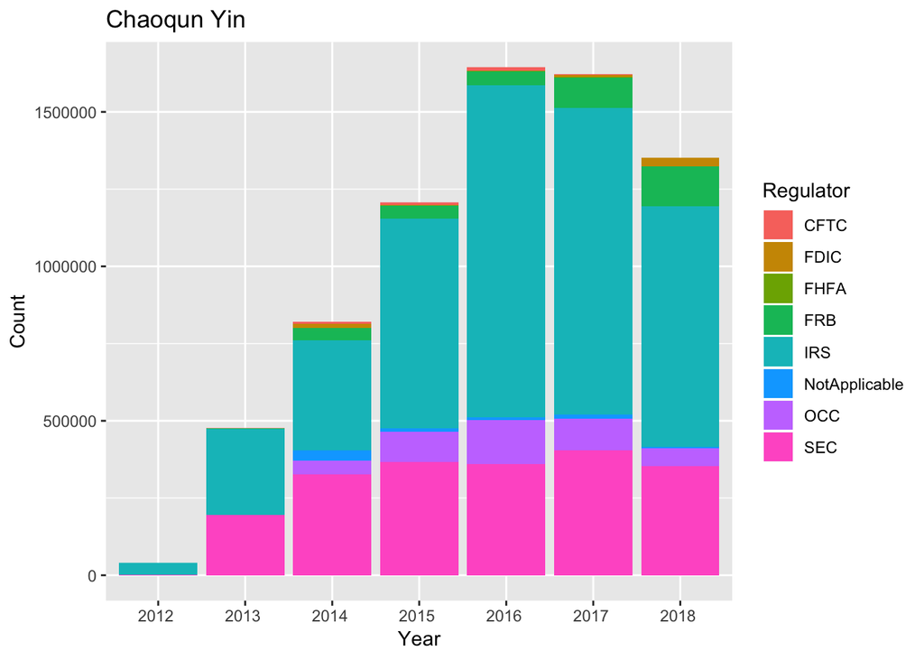

```r
ggplot(regulator , aes(x = Year,y = Count,fill = Regulator)) +
  geom_col(position = "stack") +
  labs(title = "Chaoqun Yin")
```

From the plot, the most financial criminal cases are handled by IRS and SEC.